# Ford GoBike System Data

## by Omar Hosny

## Dataset

The dataset in hand is for Ford Go Bike System data which contains information about bike trips for customers and subscribers, after dropping missing values the dataset is now 174,952 rows with 16 variables. 9 of which are numerical, 2 datetime variables and 5 other categorical variables. I'm interested in studying the trip duration and how it relates to member's age, member's gender and member's type. I'm also interested in studying the trip's start time distribution through the weekdays and weekends.

## Summary of Findings

- The maximum ratio of missing values are in 'member_birth_year' and 'member_gender' and it **doesn't exceed 5%** of the data. - Our service is more used (**almost double**) during **weekdays** compared to **weekends**.
- An average **trip duration** will vary from **200** to **1000** secs.
- The huge number of our users are between **25** and **40** years.
- Around **75%** of our users are **males**.
- More than **90%** of the users in this dataset are **subscribers**.
- for **weekdays**(from Monday to Friday), rush hours for using our service are between **7 am-9 am** and between **4 pm-6 pm**. However for **weekeneds**, the distribution is random with most of the data falls between **12 pm and 6 pm**. This suggests that our service is widely used by our users to go from and to their jobs during weekdays.
- Though males use our services more than women as shown in the Univariate data exploration(around 75% of the dataset are males). By comparing the **trip duration** between **males** and **females**, seems that there is **no much difference** between them.
- Our **customers** tend to take the bikes for **longer durations** per trip than our subscribers.
- We can see that the **age** of our **subscribers** tend to be **slight older** than the age of our **customers**.

## Key Insights For Presentation

First I want to show through the Univariate Analysis the number of trips along weekdays and weekends, distribution of trip duration, age of users in the dataset, gender distribution in our data and user types. Moving to the bivariate analysis, we can discover if there's any relation between the start hour of using the service and the weekday, trip duarion and age, trip duration and gender, trip duration and user type. At the end we will have a look on the trip duration vs age in each user type category(customer or subscriber)

## Number of Trips along weekdays

Our service is more used (almost double) during weekdays compared to weekends.

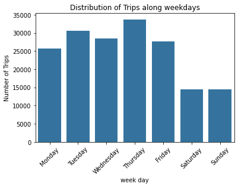

```python
base_color = sb.color_palette()[0]
order = ['Monday', 'Tuesday', 'Wednesday', 'Thursday', 'Friday', 'Saturday', 'Sunday']
sb.countplot(data=df, x='start_weekday', order=order, color=base_color, saturation=0.7);
plt.xticks(rotation=45);
plt.xlabel('week day')
plt.ylabel('Number of Trips')
plt.title('Distribution of Trips along weekdays');
```

## Trip Duration Distribution

An average trip duration will vary from 200 secs to 1000 secs

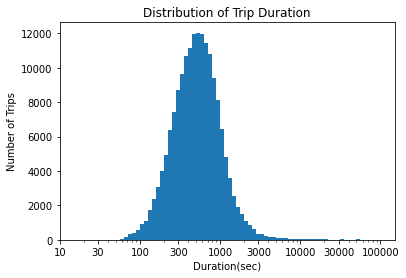

```python
bins = 10 ** np.arange(1.5, 5+0.05, 0.05)
plt.hist(data=df, x='duration_sec', bins=bins);
ticks = [10, 30, 100, 300, 1000, 3000, 10000, 30000, 100000]
labels = ["{}".format(v) for v in ticks]
plt.xlabel('Duration(sec)')
plt.ylabel('Number of Trips')
plt.title('Distribution of Trip Duration')
plt.xscale('log');
plt.xticks(ticks, labels);
```

## Distribution of Age

The huge number of our users are between 25 and 40 years.

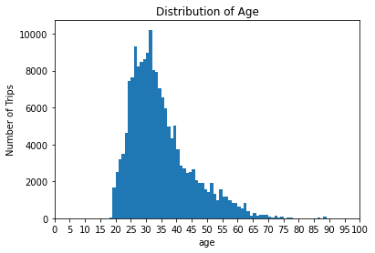

```python
bins = np.arange(10, df['age'].max()+1, 1)
plt.hist(data=df, x='age', bins=bins);
plt.xlabel('age')
plt.ylabel('Number of Trips')
plt.title('Distribution of Age');
ticks = [i for i in range(0, 105, 5)]
plt.xlim(0, 100)
plt.xticks(ticks);
```

## Gender Ratio

Around 75% of our users are males.

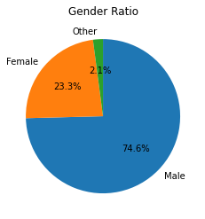

```python
sorted_counts = df['member_gender'].value_counts()

plt.pie(sorted_counts, labels = sorted_counts.index, startangle = 90, counterclock = False, autopct='%1.1f%%');

plt.title('Gender Ratio');
```

## User Type Ratio

More than 90% of the users in this dataset are subscribers.

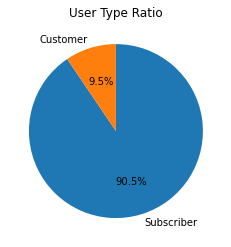

```python
sorted_counts = df['user_type'].value_counts()

plt.pie(sorted_counts, labels = sorted_counts.index, startangle = 90, counterclock = False, autopct='%1.1f%%');
plt.title('User Type Ratio');
```

## Start Hour along Weekdays

for weekdays(from Monday to Friday), rush hours are between 7 am - 9 am and between 4 pm - 6 pm. However for weekeneds, the distribution is random from 6 am to 12 pm with most of the data falls between 12 pm and 6 pm.

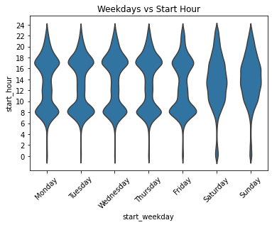

```python
base_color = sb.color_palette()[0]
sb.violinplot(data=df, x='start_weekday', y='start_hour', color=base_color, inner=None);
yticks = [i for i in range(0, 25, 2)]
plt.title('Weekdays vs Start Hour')
plt.xticks(rotation=45);
plt.yticks(yticks);
```

## Age vs Trip Duration

Again, the big bulk of our users are between 20 and 40 years with trip duration less than 1000 secs.

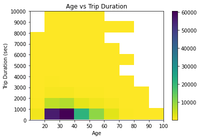

```python
bins_x = np.arange(10, 141+10, 10)
bins_y = np.arange(60, 10000+1000, 1000)
plt.hist2d(data=df, x='age', y='duration_sec', cmin=0.5, cmap='viridis_r', bins=[bins_x, bins_y]);
xticks = [i for i in range(20, 110, 10)]
yticks = [i for i in range(0, 11000, 1000)]
plt.xlim(10, 100)
plt.ylim(0, 10000)
plt.colorbar()
plt.title('Age vs Trip Duration')
plt.xlabel('Age')
plt.ylabel('Trip Duration (sec)');
plt.xticks(xticks)
plt.yticks(yticks);
```

## Trip Duration Distribution Among Gender

Though males use our services more than women as shown in the Univariate data exploration(around 75% of the dataset are males). By comparing the trip duration between males and females, seems that there is no much difference between them.

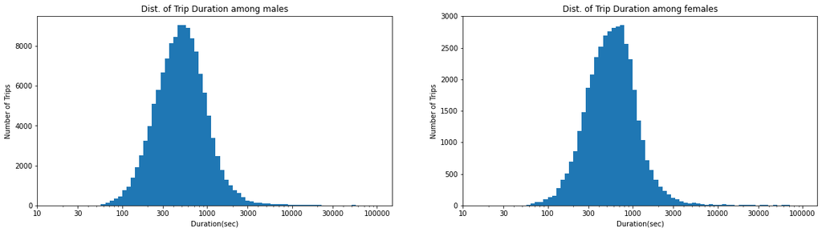

```python
plt.figure(figsize = [20, 5])

df_male = df[df['member_gender'] == 'Male']
df_female = df[df['member_gender'] == 'Female']
df_other = df[df['member_gender'] == 'Other']

plt.subplot(1, 2, 1)
bins = 10 ** np.arange(1.5, 5+0.05, 0.05)
plt.hist(data=df_male, x='duration_sec', bins=bins);
ticks = [10, 30, 100, 300, 1000, 3000, 10000, 30000, 100000]
labels = ["{}".format(v) for v in ticks]
plt.xlabel('Duration(sec)')
plt.ylabel('Number of Trips')
plt.title('Dist. of Trip Duration among males')
plt.xscale('log');
plt.xticks(ticks, labels);

plt.subplot(1, 2, 2)
bins = 10 ** np.arange(1.5, 5+0.05, 0.05)
plt.hist(data=df_female, x='duration_sec', bins=bins);
ticks = [10, 30, 100, 300, 1000, 3000, 10000, 30000, 100000]
labels = ["{}".format(v) for v in ticks]
plt.xlabel('Duration(sec)')
plt.ylabel('Number of Trips')
plt.title('Dist. of Trip Duration among females')
plt.xscale('log');
plt.xticks(ticks, labels);
```

## User Type Vs Trip Duration

Customers tend to take the bikes for longer durations than our subscribers.

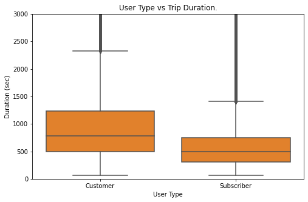

```python
plt.figure(figsize = [8, 5])
base_color = sb.color_palette()[1]
sb.boxplot(data = df, x = 'user_type', y = 'duration_sec', color = base_color)
plt.ylim(0, 3000)
plt.xlabel('User Type')
plt.ylabel('Duration (sec)')
plt.title('User Type vs Trip Duration.')
plt.show();
```

## User Type, Age, And Trip Duration

The chart on the left confirms that the duration spent by customers tend to be higher than of our subscribers. Also, by having a look on both graphs, we can see that the age of our subscribers tend to be slight older than the age of our customers.

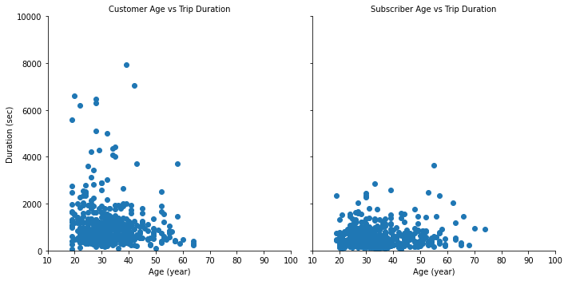

```python
g = sb.FacetGrid(data = df_subset, col = 'user_type', col_wrap=2, size = 5,
                 xlim = [10, 100], ylim = [0, 10000])
g.map(plt.scatter, 'age', 'duration_sec')
g.set_xlabels('Age (year)')
g.set_ylabels('Duration (sec)')
# g.set_title("User Type, Age, And Trip Duration");
g.set_titles(col_template="{col_name} Age vs Trip Duration")
plt.show();
```